# Tugas Pertemuan 4

# White Noise

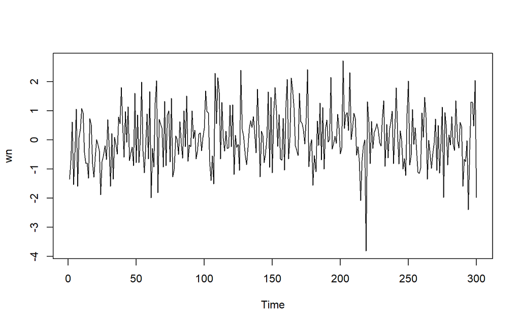

```r
set.seed(1080)
wn <- rnorm(300)
ts.plot(wn)
```

# MA(2)

MA(2) dengan parameter $\theta_1 = 0.4$ dan $\theta_2 = 0.6$ sebanyak 300 observasi.

Model:
$$Y_t = e_t + 0.4e_{t-1} +
0.6e_{t-2}$$

## Pembangkitan Data

### Manual

```r
set.seed(1080)
ma <- wn[1]
ma[2] <- wn[2] + 0.4 * wn[1]
```

```r
for(i in 3:300){
   ma[i] <- wn[i] + 0.4 * wn[i - 1] + 0.6 * wn[i-2]
}
ma
```

```
##   [1] -1.347674753 -1.246480955 -0.478143490 -1.710638486 -0.669698160
##   [6] -0.024998308 -1.426994639  0.087937613 -0.544867797  1.282280953
##  [11]  1.586280190  0.586518003 -0.419518007 -1.374261768 -2.112769715
##  [16] -0.271350908  0.032430282 -0.179966809 -1.291922673 -1.579329495
##  [21] -0.981458834 -0.499993425 -0.426467138 -2.130261402 -1.724149465
##  [26] -1.980555238 -0.861836380 -1.076452422  0.319866994 -0.347219158
##  [31] -1.259451906 -0.551813085 -2.210953311 -0.312406102 -0.916542863
##  [36] -0.485864290  0.506264200  0.582079157  2.502913909  1.570527655
##  [41]  0.695712783  1.045336627 -0.041178962  1.701667955 -0.293569799
##  [46] -0.052368999 -0.853219801 -1.257312177  1.100198203 -0.671619528
##  [51]  1.513924372 -0.905323937  0.227731751  1.527266178  0.424162997
##  [56] -0.083925610 -0.867918379  0.148218858 -0.408343893  1.942436017
##  [61] -1.710294342 -0.080443052 -2.232537663  0.738737895  1.999220935
##  [66] -0.223753967  1.215829641 -0.253463511  1.053065652 -0.436612024
##  [71]  1.196179208 -0.906626799  1.289843370  0.811313937  0.150646715
```

[output cut: 45 more lines]

### Dengan arima.sim

```r
ma1 <- arima.sim(list(order=c(0,0,2), ma=c(0.4,0.6)), n=300)
ma1
```

```
## Time Series:
## Start = 1
## End = 300
## Frequency = 1
##   [1] -0.478143490 -1.710638486 -0.669698160 -0.024998308 -1.426994639
##   [6]  0.087937613 -0.544867797  1.282280953  1.586280190  0.586518003
##  [11] -0.419518007 -1.374261768 -2.112769715 -0.271350908  0.032430282
##  [16] -0.179966809 -1.291922673 -1.579329495 -0.981458834 -0.499993425
##  [21] -0.426467138 -2.130261402 -1.724149465 -1.980555238 -0.861836380
##  [26] -1.076452422  0.319866994 -0.347219158 -1.259451906 -0.551813085
##  [31] -2.210953311 -0.312406102 -0.916542863 -0.485864290  0.506264200
##  [36]  0.582079157  2.502913909  1.570527655  0.695712783  1.045336627
##  [41] -0.041178962  1.701667955 -0.293569799 -0.052368999 -0.853219801
##  [46] -1.257312177  1.100198203 -0.671619528  1.513924372 -0.905323937
##  [51]  0.227731751  1.527266178  0.424162997 -0.083925610 -0.867918379
```

[output cut: 49 more lines]

## Plot

### Plot Time Series

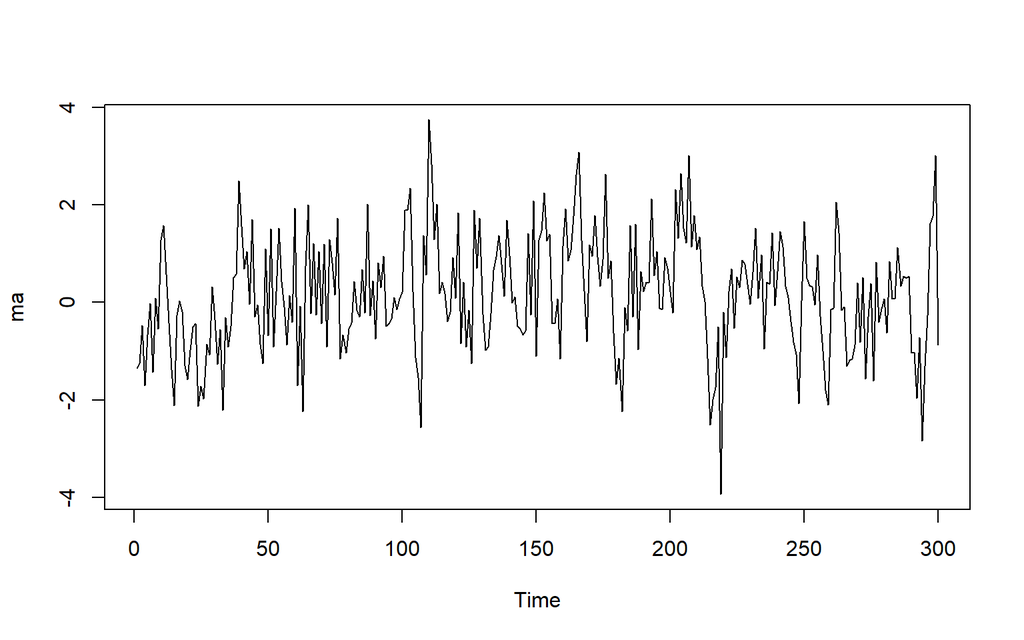

```r
ts.plot(ma)
```

### Plot ACF

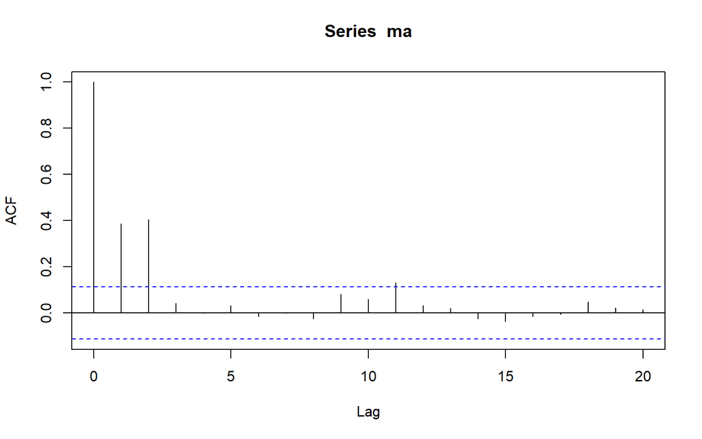

```r
acf(ma,lag.max = 20)
```

### Plot PACF

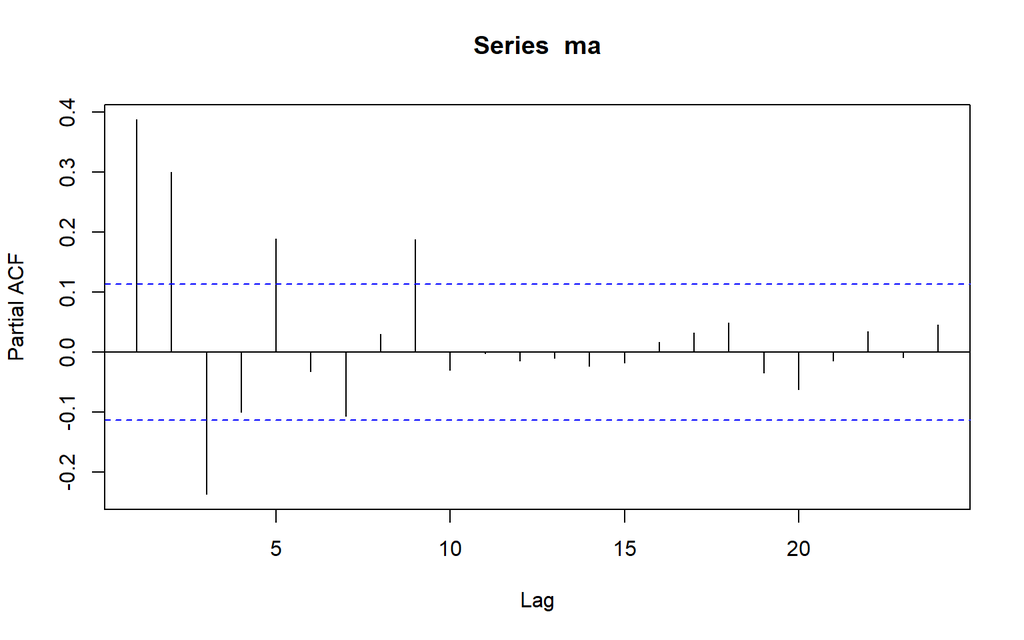

```r
pacf(ma)
```

### Plot EACF

```r
TSA::eacf(ma)
```

```
## AR/MA
##   0 1 2 3 4 5 6 7 8 9 10 11 12 13
## 0 x x o o o o o o o o x  o  o  o
## 1 x x o o o o o o o o x  o  o  o
## 2 x x o x o o o o o o x  o  o  o
## 3 x x x o x o o o o o o  o  o  o
## 4 x x o o o o o o o o o  o  o  o
## 5 x x o o o o o o o o o  o  o  o
## 6 x x o o x x o o o o o  o  o  o
## 7 x x o x x o x o x o o  o  o  o
```

Berdasarkan plot time series, pergerakan data bangkitan berada di sekitar rataan konstan $E[Y_t] = 0$. Hal ini menunjukkan bahwa data MA(2) yang dibangkitkan stasioner dalam rataan.

Plot ACF menunjukkan cut off pada lag ke-2 dan plot PACF menunjukkan tail off dan membentuk gelombang sinus. Hal ini menandakan proses MA(2).

Berdasarkan pola segitiga nol pada plot EACF, terlihat bahwa segitiga nol berada pada AR(0) dan MA(2). Hal ini memperkuat bahwa model teridentifikasi sebagai MA(2).

## Scatter Plot

### Antara $Y_t$ dengan $Y_{t-1}$

```r
#Yt
yt_ma <- ma[-1]
yt_ma
```

```
##   [1] -1.246480955 -0.478143490 -1.710638486 -0.669698160 -0.024998308
##   [6] -1.426994639  0.087937613 -0.544867797  1.282280953  1.586280190
##  [11]  0.586518003 -0.419518007 -1.374261768 -2.112769715 -0.271350908
##  [16]  0.032430282 -0.179966809 -1.291922673 -1.579329495 -0.981458834
##  [21] -0.499993425 -0.426467138 -2.130261402 -1.724149465 -1.980555238
##  [26] -0.861836380 -1.076452422  0.319866994 -0.347219158 -1.259451906
##  [31] -0.551813085 -2.210953311 -0.312406102 -0.916542863 -0.485864290
##  [36]  0.506264200  0.582079157  2.502913909  1.570527655  0.695712783
##  [41]  1.045336627 -0.041178962  1.701667955 -0.293569799 -0.052368999
##  [46] -0.853219801 -1.257312177  1.100198203 -0.671619528  1.513924372
##  [51] -0.905323937  0.227731751  1.527266178  0.424162997 -0.083925610
##  [56] -0.867918379  0.148218858 -0.408343893  1.942436017 -1.710294342
##  [61] -0.080443052 -2.232537663  0.738737895  1.999220935 -0.223753967
##  [66]  1.215829641 -0.253463511  1.053065652 -0.436612024  1.196179208
##  [71] -0.906626799  1.289843370  0.811313937  0.150646715  1.723958120
```

[output cut: 45 more lines]

```r
#Yt-1
yt_1_ma <- ma[-300]
yt_1_ma
```

```
##   [1] -1.347674753 -1.246480955 -0.478143490 -1.710638486 -0.669698160
##   [6] -0.024998308 -1.426994639  0.087937613 -0.544867797  1.282280953
##  [11]  1.586280190  0.586518003 -0.419518007 -1.374261768 -2.112769715
##  [16] -0.271350908  0.032430282 -0.179966809 -1.291922673 -1.579329495
##  [21] -0.981458834 -0.499993425 -0.426467138 -2.130261402 -1.724149465
##  [26] -1.980555238 -0.861836380 -1.076452422  0.319866994 -0.347219158
##  [31] -1.259451906 -0.551813085 -2.210953311 -0.312406102 -0.916542863
##  [36] -0.485864290  0.506264200  0.582079157  2.502913909  1.570527655
##  [41]  0.695712783  1.045336627 -0.041178962  1.701667955 -0.293569799
##  [46] -0.052368999 -0.853219801 -1.257312177  1.100198203 -0.671619528
##  [51]  1.513924372 -0.905323937  0.227731751  1.527266178  0.424162997
##  [56] -0.083925610 -0.867918379  0.148218858 -0.408343893  1.942436017
##  [61] -1.710294342 -0.080443052 -2.232537663  0.738737895  1.999220935
##  [66] -0.223753967  1.215829641 -0.253463511  1.053065652 -0.436612024
##  [71]  1.196179208 -0.906626799  1.289843370  0.811313937  0.150646715
```

[output cut: 45 more lines]

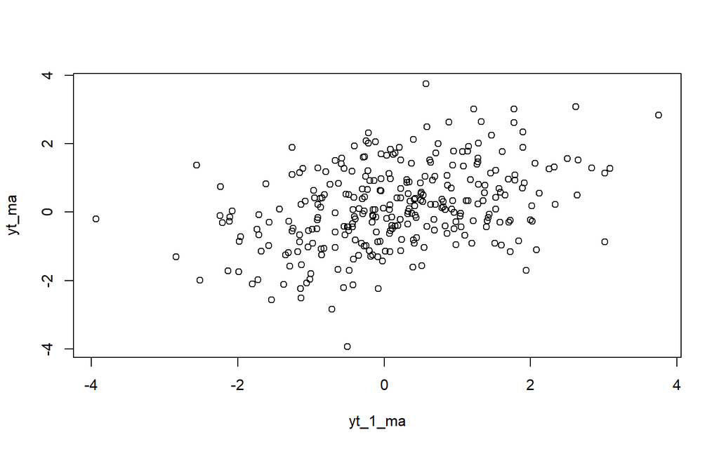

```r
plot(y=yt_ma,x=yt_1_ma)
```

### Antara $Y_t$ dengan $Y_{t-2}$

```r
#Yt
yt_ma2 <- ma[-c(1,2)]
yt_ma2
```

```
##   [1] -0.478143490 -1.710638486 -0.669698160 -0.024998308 -1.426994639
##   [6]  0.087937613 -0.544867797  1.282280953  1.586280190  0.586518003
##  [11] -0.419518007 -1.374261768 -2.112769715 -0.271350908  0.032430282
##  [16] -0.179966809 -1.291922673 -1.579329495 -0.981458834 -0.499993425
##  [21] -0.426467138 -2.130261402 -1.724149465 -1.980555238 -0.861836380
##  [26] -1.076452422  0.319866994 -0.347219158 -1.259451906 -0.551813085
##  [31] -2.210953311 -0.312406102 -0.916542863 -0.485864290  0.506264200
##  [36]  0.582079157  2.502913909  1.570527655  0.695712783  1.045336627
##  [41] -0.041178962  1.701667955 -0.293569799 -0.052368999 -0.853219801
##  [46] -1.257312177  1.100198203 -0.671619528  1.513924372 -0.905323937
##  [51]  0.227731751  1.527266178  0.424162997 -0.083925610 -0.867918379
##  [56]  0.148218858 -0.408343893  1.942436017 -1.710294342 -0.080443052
##  [61] -2.232537663  0.738737895  1.999220935 -0.223753967  1.215829641
##  [66] -0.253463511  1.053065652 -0.436612024  1.196179208 -0.906626799
##  [71]  1.289843370  0.811313937  0.150646715  1.723958120 -1.153495777
```

[output cut: 45 more lines]

```r
#Yt-2
yt_2_ma <- ma[-c(299,300)]
yt_2_ma
```

```
##   [1] -1.347674753 -1.246480955 -0.478143490 -1.710638486 -0.669698160
##   [6] -0.024998308 -1.426994639  0.087937613 -0.544867797  1.282280953
##  [11]  1.586280190  0.586518003 -0.419518007 -1.374261768 -2.112769715
##  [16] -0.271350908  0.032430282 -0.179966809 -1.291922673 -1.579329495
##  [21] -0.981458834 -0.499993425 -0.426467138 -2.130261402 -1.724149465
##  [26] -1.980555238 -0.861836380 -1.076452422  0.319866994 -0.347219158
##  [31] -1.259451906 -0.551813085 -2.210953311 -0.312406102 -0.916542863
##  [36] -0.485864290  0.506264200  0.582079157  2.502913909  1.570527655
##  [41]  0.695712783  1.045336627 -0.041178962  1.701667955 -0.293569799
##  [46] -0.052368999 -0.853219801 -1.257312177  1.100198203 -0.671619528
##  [51]  1.513924372 -0.905323937  0.227731751  1.527266178  0.424162997
##  [56] -0.083925610 -0.867918379  0.148218858 -0.408343893  1.942436017
##  [61] -1.710294342 -0.080443052 -2.232537663  0.738737895  1.999220935
##  [66] -0.223753967  1.215829641 -0.253463511  1.053065652 -0.436612024
##  [71]  1.196179208 -0.906626799  1.289843370  0.811313937  0.150646715
```

[output cut: 45 more lines]

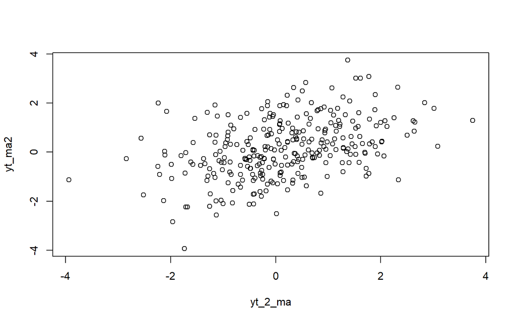

```r
plot(y=yt_ma2,x=yt_2_ma)
```

### Antara $Y_t$ dengan $Y_{t-3}$

```r
#Yt
yt_ma3 <- ma[-c(1,2,3)]
yt_ma3
```

```
##   [1] -1.710638486 -0.669698160 -0.024998308 -1.426994639  0.087937613
##   [6] -0.544867797  1.282280953  1.586280190  0.586518003 -0.419518007
##  [11] -1.374261768 -2.112769715 -0.271350908  0.032430282 -0.179966809
##  [16] -1.291922673 -1.579329495 -0.981458834 -0.499993425 -0.426467138
##  [21] -2.130261402 -1.724149465 -1.980555238 -0.861836380 -1.076452422
##  [26]  0.319866994 -0.347219158 -1.259451906 -0.551813085 -2.210953311
##  [31] -0.312406102 -0.916542863 -0.485864290  0.506264200  0.582079157
##  [36]  2.502913909  1.570527655  0.695712783  1.045336627 -0.041178962
##  [41]  1.701667955 -0.293569799 -0.052368999 -0.853219801 -1.257312177
##  [46]  1.100198203 -0.671619528  1.513924372 -0.905323937  0.227731751
##  [51]  1.527266178  0.424162997 -0.083925610 -0.867918379  0.148218858
##  [56] -0.408343893  1.942436017 -1.710294342 -0.080443052 -2.232537663
##  [61]  0.738737895  1.999220935 -0.223753967  1.215829641 -0.253463511
##  [66]  1.053065652 -0.436612024  1.196179208 -0.906626799  1.289843370
##  [71]  0.811313937  0.150646715  1.723958120 -1.153495777 -0.667762785
```

[output cut: 45 more lines]

```r
##Yt-3
yt_3_ma <- ma[-c(298,299,300)]
yt_3_ma
```

```
##   [1] -1.347674753 -1.246480955 -0.478143490 -1.710638486 -0.669698160
##   [6] -0.024998308 -1.426994639  0.087937613 -0.544867797  1.282280953
##  [11]  1.586280190  0.586518003 -0.419518007 -1.374261768 -2.112769715
##  [16] -0.271350908  0.032430282 -0.179966809 -1.291922673 -1.579329495
##  [21] -0.981458834 -0.499993425 -0.426467138 -2.130261402 -1.724149465
##  [26] -1.980555238 -0.861836380 -1.076452422  0.319866994 -0.347219158
##  [31] -1.259451906 -0.551813085 -2.210953311 -0.312406102 -0.916542863
##  [36] -0.485864290  0.506264200  0.582079157  2.502913909  1.570527655
##  [41]  0.695712783  1.045336627 -0.041178962  1.701667955 -0.293569799
##  [46] -0.052368999 -0.853219801 -1.257312177  1.100198203 -0.671619528
##  [51]  1.513924372 -0.905323937  0.227731751  1.527266178  0.424162997
##  [56] -0.083925610 -0.867918379  0.148218858 -0.408343893  1.942436017
##  [61] -1.710294342 -0.080443052 -2.232537663  0.738737895  1.999220935
##  [66] -0.223753967  1.215829641 -0.253463511  1.053065652 -0.436612024
##  [71]  1.196179208 -0.906626799  1.289843370  0.811313937  0.150646715
```

[output cut: 45 more lines]

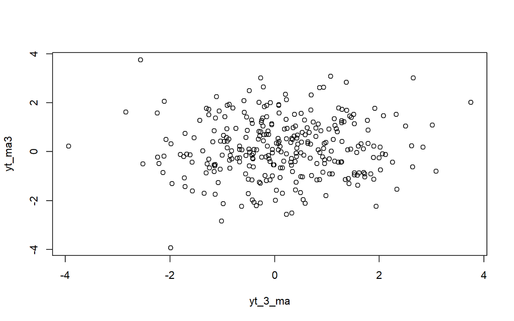

```r
plot(y=yt_ma3,x=yt_3_ma)
```

## Autokorelasi

### Antara $Y_t$ dengan $Y_{t-1}$

```r
cor(yt_ma,yt_1_ma)
```

```
## [1] 0.3886682
```

Korelasi berdasarkan perhitungan teoritis
$$\rho_1 = \frac{-\theta_1+\theta_1\theta_2}
{1+\theta_1^2+\theta_2^2} = \frac{-(-0.4)+(-0.4)\times(-0.6)}
{1+(-0.4)^2+(-0.6)^2} = \frac{0.64}{1.52} = 0.421$$

### Antara $Y_t$ dengan $Y_{t-2}$

```r
cor(yt_ma2,yt_2_ma)
```

```
## [1] 0.411316
```

Korelasi berdasarkan pendekatan teoritis
$$\rho_2 = \frac{-\theta_2}
{1+\theta_1^2+\theta_2^2} = \frac{-(-0.6)}
{1+(0.4)^2+(0.6)^2} = \frac{0.6}{1.52} = 0.395$$

### Antara $Y_t$ dengan $Y_{t-3}$

```r
cor(yt_ma3,yt_3_ma)
```

```
## [1] 0.04357092
```

Korelasi berdasarkan pendekatan teoritis adalah 0

Berdasarkan Scatter plot:

Hubungan $Y_t$ dan $Y_{t-1}$ bernilai positif, hal tersebut ditunjukkan juga dengan nilai korelasi data bangkitan = 0.388 dan berdekatan dengan korelasi secara teoritis = 0.421.

Hubungan $Y_t$ dan $Y_{t-2}$ bernilai positif, hal tersebut ditunjukkan juga dengan nilai korelasi data bangkitan = 0.411 dan berdekatan dengan korelasi secara teoritis = 0.395.

$Y_t$ dan $Y_{t-3}$ cenderung tidak memiliki hubungan, hal tersebut ditunjukkan juga dengan nilai korelasi data bangkitan yang mendekati nol dan sesuai dengan pendekatan teoritis ($\rho_k = 0$, $k\ge 3$).

# AR(2)

AR(2) dengan parameter $\phi_1 = 0.5$ dan $\phi_2 = 0.2$ sebanyak 300 obervasi.

Model:
$$Y_t = e_t + 0.5Y_{t-1} +
0.2Y_{t-2}$$

## Pembangkitan Data

### Manual

```r
set.seed(1080)
ar <- wn[1]
ar[2] <- wn[2] + 0.5*wn[1]
```

```r
for (i in 3:300) {
  ar[i] <- wn[i] + 0.5*ar[i-1] + 0.2*ar[i-2]
  }
ar
```

```
##   [1] -1.347674753 -1.381248430 -0.346733383 -1.981178544 -1.485064712
##   [6] -0.074777568 -1.931915306 -0.892364420 -0.454344419  0.672218271
##  [11]  1.173442585  0.289683998 -0.424316512 -0.948055844 -1.871818967
##  [16] -0.395399830 -0.043925110 -0.930337263 -1.751041589 -1.632505722
##  [21] -1.153300262 -1.065858583 -1.132870109 -2.664531483 -2.307450884
##  [26] -2.236787701 -1.772491350 -2.002919130 -0.652800082 -0.953876577
##  [31] -2.198087779 -1.069260875 -2.319070951 -1.280199567 -1.250838296
##  [36] -1.364466472 -0.144779138  0.211552038  1.884427085  1.497907907
##  [41]  0.531634434  1.540387026  0.801869109  1.855547494  0.380754331
##  [46]  0.104153640 -0.117622963 -0.922552856  1.116736413 -0.407633604
##  [51]  0.885128888 -0.421630833 -0.012349510  1.897790338  0.562407682
##  [56] -0.462531423 -0.306974670  0.651477435 -0.390074235  1.600978961
##  [61] -1.261457134 -0.596835474 -1.478366687  0.423032085  1.959025145
##  [66] -0.745857468  0.732787055  0.764180094  0.934583430 -0.307033515
##  [71]  1.356882053 -0.262688576  0.987675378  1.441390348  0.160254862
```

[output cut: 45 more lines]

### Dengan arima.sim

```r
ar1 <- arima.sim(list(order=c(2,0,0), ar=c(0.5,0.2)), n=300)
ar1
```

```
## Time Series:
## Start = 1
## End = 300
## Frequency = 1
##   [1] -2.236787701 -1.772491350 -2.002919130 -0.652800082 -0.953876577
##   [6] -2.198087779 -1.069260875 -2.319070951 -1.280199567 -1.250838296
##  [11] -1.364466472 -0.144779138  0.211552038  1.884427085  1.497907907
##  [16]  0.531634434  1.540387026  0.801869109  1.855547494  0.380754331
##  [21]  0.104153640 -0.117622963 -0.922552856  1.116736413 -0.407633604
##  [26]  0.885128888 -0.421630833 -0.012349510  1.897790338  0.562407682
##  [31] -0.462531423 -0.306974670  0.651477435 -0.390074235  1.600978961
##  [36] -1.261457134 -0.596835474 -1.478366687  0.423032085  1.959025145
##  [41] -0.745857468  0.732787055  0.764180094  0.934583430 -0.307033515
##  [46]  1.356882053 -0.262688576  0.987675378  1.441390348  0.160254862
##  [51]  1.795499551 -0.339747417 -0.826973747 -0.344347803 -0.327720915
```

[output cut: 49 more lines]

## Plot

### Plot Time Series

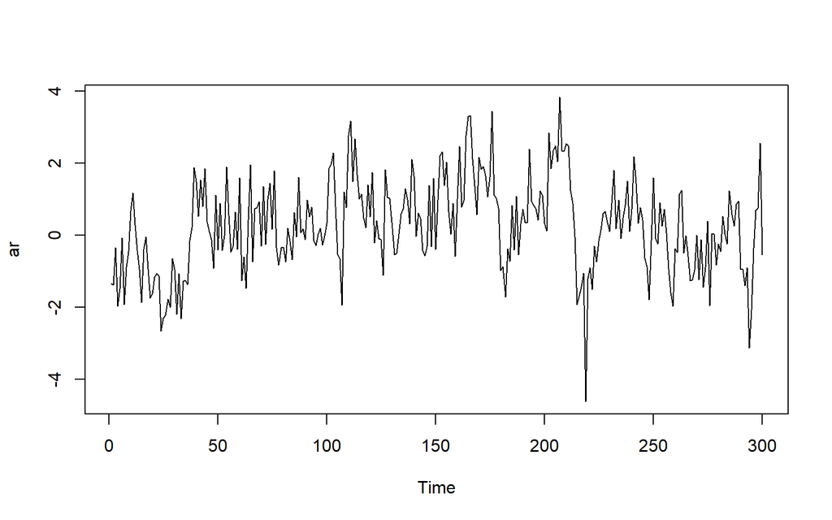

```r
ts.plot(ar)
```

### Plot ACF

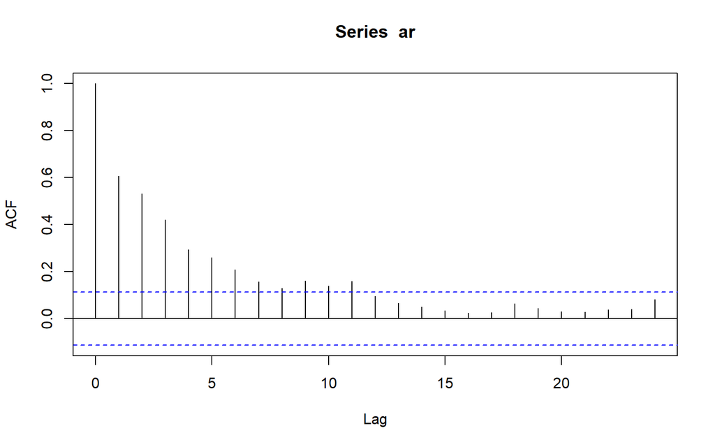

```r
acf(ar)
```

### Plot PACF

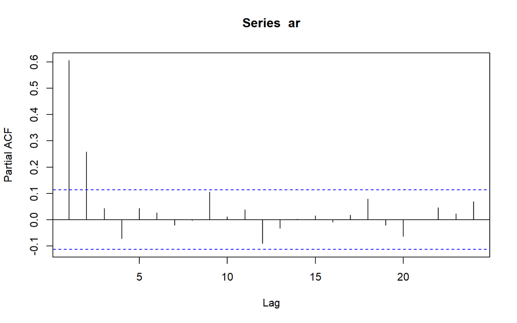

```r
pacf(ar)
```

### Plot EACF

```r
TSA::eacf(ar)
```

```
## AR/MA
##   0 1 2 3 4 5 6 7 8 9 10 11 12 13
## 0 x x x x x x x x x x x  o  o  o
## 1 x o o o o o o o o o x  o  o  o
## 2 x x o o o o o o o o o  o  o  o
## 3 x o o o o o o o o o x  o  o  o
## 4 x x x o o o o o o o o  o  o  o
## 5 x x x o o o o o o o o  o  o  o
## 6 x x o x o o o o o o o  o  o  o
## 7 x o o x o o o o o o o  o  o  o
```

Berdasarkan plot time series, terlihat bahwa data cenderung stasioner dalam rataan. Selain itu persamaan karakteristik AR(2):$1-0.5B-0.2B^2$ akar-akarnya memenuhi syarat kestasioneran $|\phi_2|=|0.2| < 1$, $\phi_1+\phi_2 = 0.7 <1$, dan $\phi_2-\phi_1 = -0.3 <1$.

Plot ACF menunjukkan tail off dan plot ACF mengalami cut off pada lag ke-2. Hal ini menandakan proses AR(2).

Berdasarkan pola segitiga nol pada plot EACF, terlihat bahwa pola berada pada AR(1) dan MA(1). Hal ini menandakan bahwa proses data bangkitan bukan merupakan AR(2)

## Scatter Plot

### Antara $Y_t$ dengan $Y_{t-1}$

```r
#Yt
yt_ar <- ar[-1]
yt_ar
```

```
##   [1] -1.381248430 -0.346733383 -1.981178544 -1.485064712 -0.074777568
##   [6] -1.931915306 -0.892364420 -0.454344419  0.672218271  1.173442585
##  [11]  0.289683998 -0.424316512 -0.948055844 -1.871818967 -0.395399830
##  [16] -0.043925110 -0.930337263 -1.751041589 -1.632505722 -1.153300262
##  [21] -1.065858583 -1.132870109 -2.664531483 -2.307450884 -2.236787701
##  [26] -1.772491350 -2.002919130 -0.652800082 -0.953876577 -2.198087779
##  [31] -1.069260875 -2.319070951 -1.280199567 -1.250838296 -1.364466472
##  [36] -0.144779138  0.211552038  1.884427085  1.497907907  0.531634434
##  [41]  1.540387026  0.801869109  1.855547494  0.380754331  0.104153640
##  [46] -0.117622963 -0.922552856  1.116736413 -0.407633604  0.885128888
##  [51] -0.421630833 -0.012349510  1.897790338  0.562407682 -0.462531423
##  [56] -0.306974670  0.651477435 -0.390074235  1.600978961 -1.261457134
##  [61] -0.596835474 -1.478366687  0.423032085  1.959025145 -0.745857468
##  [66]  0.732787055  0.764180094  0.934583430 -0.307033515  1.356882053
##  [71] -0.262688576  0.987675378  1.441390348  0.160254862  1.795499551
```

[output cut: 45 more lines]

```r
#Yt-1
yt_1_ar <- ar[-300]
yt_1_ar
```

```
##   [1] -1.347674753 -1.381248430 -0.346733383 -1.981178544 -1.485064712
##   [6] -0.074777568 -1.931915306 -0.892364420 -0.454344419  0.672218271
##  [11]  1.173442585  0.289683998 -0.424316512 -0.948055844 -1.871818967
##  [16] -0.395399830 -0.043925110 -0.930337263 -1.751041589 -1.632505722
##  [21] -1.153300262 -1.065858583 -1.132870109 -2.664531483 -2.307450884
##  [26] -2.236787701 -1.772491350 -2.002919130 -0.652800082 -0.953876577
##  [31] -2.198087779 -1.069260875 -2.319070951 -1.280199567 -1.250838296
##  [36] -1.364466472 -0.144779138  0.211552038  1.884427085  1.497907907
##  [41]  0.531634434  1.540387026  0.801869109  1.855547494  0.380754331
##  [46]  0.104153640 -0.117622963 -0.922552856  1.116736413 -0.407633604
##  [51]  0.885128888 -0.421630833 -0.012349510  1.897790338  0.562407682
##  [56] -0.462531423 -0.306974670  0.651477435 -0.390074235  1.600978961
##  [61] -1.261457134 -0.596835474 -1.478366687  0.423032085  1.959025145
##  [66] -0.745857468  0.732787055  0.764180094  0.934583430 -0.307033515
##  [71]  1.356882053 -0.262688576  0.987675378  1.441390348  0.160254862
```

[output cut: 45 more lines]

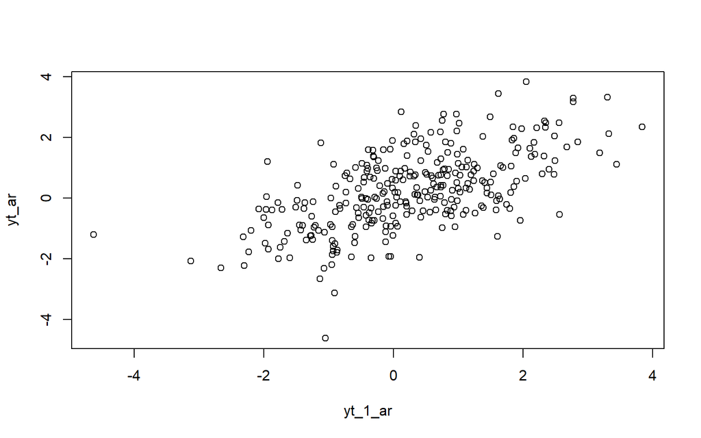

```r
plot(y=yt_ar,x=yt_1_ar)
```

### Antara $Y_t$ dengan $Y_{t-2}$

```r
#Yt
yt_ar2 <- ar[-c(1,2)]
yt_ar2
```

```
##   [1] -0.346733383 -1.981178544 -1.485064712 -0.074777568 -1.931915306
##   [6] -0.892364420 -0.454344419  0.672218271  1.173442585  0.289683998
##  [11] -0.424316512 -0.948055844 -1.871818967 -0.395399830 -0.043925110
##  [16] -0.930337263 -1.751041589 -1.632505722 -1.153300262 -1.065858583
##  [21] -1.132870109 -2.664531483 -2.307450884 -2.236787701 -1.772491350
##  [26] -2.002919130 -0.652800082 -0.953876577 -2.198087779 -1.069260875
##  [31] -2.319070951 -1.280199567 -1.250838296 -1.364466472 -0.144779138
##  [36]  0.211552038  1.884427085  1.497907907  0.531634434  1.540387026
##  [41]  0.801869109  1.855547494  0.380754331  0.104153640 -0.117622963
##  [46] -0.922552856  1.116736413 -0.407633604  0.885128888 -0.421630833
##  [51] -0.012349510  1.897790338  0.562407682 -0.462531423 -0.306974670
##  [56]  0.651477435 -0.390074235  1.600978961 -1.261457134 -0.596835474
##  [61] -1.478366687  0.423032085  1.959025145 -0.745857468  0.732787055
##  [66]  0.764180094  0.934583430 -0.307033515  1.356882053 -0.262688576
##  [71]  0.987675378  1.441390348  0.160254862  1.795499551 -0.339747417
```

[output cut: 45 more lines]

```r
#Yt-2
yt_2_ar <- ar[-c(299,300)]
yt_2_ar
```

```
##   [1] -1.347674753 -1.381248430 -0.346733383 -1.981178544 -1.485064712
##   [6] -0.074777568 -1.931915306 -0.892364420 -0.454344419  0.672218271
##  [11]  1.173442585  0.289683998 -0.424316512 -0.948055844 -1.871818967
##  [16] -0.395399830 -0.043925110 -0.930337263 -1.751041589 -1.632505722
##  [21] -1.153300262 -1.065858583 -1.132870109 -2.664531483 -2.307450884
##  [26] -2.236787701 -1.772491350 -2.002919130 -0.652800082 -0.953876577
##  [31] -2.198087779 -1.069260875 -2.319070951 -1.280199567 -1.250838296
##  [36] -1.364466472 -0.144779138  0.211552038  1.884427085  1.497907907
##  [41]  0.531634434  1.540387026  0.801869109  1.855547494  0.380754331
##  [46]  0.104153640 -0.117622963 -0.922552856  1.116736413 -0.407633604
##  [51]  0.885128888 -0.421630833 -0.012349510  1.897790338  0.562407682
##  [56] -0.462531423 -0.306974670  0.651477435 -0.390074235  1.600978961
##  [61] -1.261457134 -0.596835474 -1.478366687  0.423032085  1.959025145
##  [66] -0.745857468  0.732787055  0.764180094  0.934583430 -0.307033515
##  [71]  1.356882053 -0.262688576  0.987675378  1.441390348  0.160254862
```

[output cut: 45 more lines]

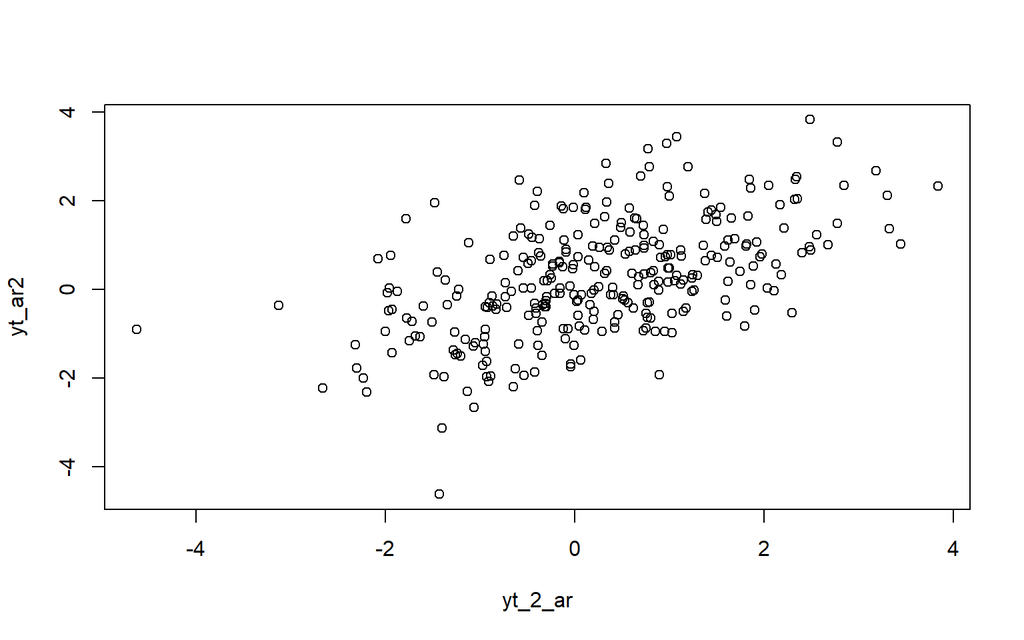

```r
plot(y=yt_ar2,x=yt_2_ar)
```

### Antara $Y_t$ dengan $Y_{t-3}$

```r
#Yt
yt_ar3 <- ar[-c(1,2,3)]
yt_ar3
```

```
##   [1] -1.981178544 -1.485064712 -0.074777568 -1.931915306 -0.892364420
##   [6] -0.454344419  0.672218271  1.173442585  0.289683998 -0.424316512
##  [11] -0.948055844 -1.871818967 -0.395399830 -0.043925110 -0.930337263
##  [16] -1.751041589 -1.632505722 -1.153300262 -1.065858583 -1.132870109
##  [21] -2.664531483 -2.307450884 -2.236787701 -1.772491350 -2.002919130
##  [26] -0.652800082 -0.953876577 -2.198087779 -1.069260875 -2.319070951
##  [31] -1.280199567 -1.250838296 -1.364466472 -0.144779138  0.211552038
##  [36]  1.884427085  1.497907907  0.531634434  1.540387026  0.801869109
##  [41]  1.855547494  0.380754331  0.104153640 -0.117622963 -0.922552856
##  [46]  1.116736413 -0.407633604  0.885128888 -0.421630833 -0.012349510
##  [51]  1.897790338  0.562407682 -0.462531423 -0.306974670  0.651477435
##  [56] -0.390074235  1.600978961 -1.261457134 -0.596835474 -1.478366687
##  [61]  0.423032085  1.959025145 -0.745857468  0.732787055  0.764180094
##  [66]  0.934583430 -0.307033515  1.356882053 -0.262688576  0.987675378
##  [71]  1.441390348  0.160254862  1.795499551 -0.339747417 -0.826973747
```

[output cut: 45 more lines]

```r
#Yt-3
yt_3_ar <- ar[-c(298,299,300)]
yt_3_ar
```

```
##   [1] -1.347674753 -1.381248430 -0.346733383 -1.981178544 -1.485064712
##   [6] -0.074777568 -1.931915306 -0.892364420 -0.454344419  0.672218271
##  [11]  1.173442585  0.289683998 -0.424316512 -0.948055844 -1.871818967
##  [16] -0.395399830 -0.043925110 -0.930337263 -1.751041589 -1.632505722
##  [21] -1.153300262 -1.065858583 -1.132870109 -2.664531483 -2.307450884
##  [26] -2.236787701 -1.772491350 -2.002919130 -0.652800082 -0.953876577
##  [31] -2.198087779 -1.069260875 -2.319070951 -1.280199567 -1.250838296
##  [36] -1.364466472 -0.144779138  0.211552038  1.884427085  1.497907907
##  [41]  0.531634434  1.540387026  0.801869109  1.855547494  0.380754331
##  [46]  0.104153640 -0.117622963 -0.922552856  1.116736413 -0.407633604
##  [51]  0.885128888 -0.421630833 -0.012349510  1.897790338  0.562407682
##  [56] -0.462531423 -0.306974670  0.651477435 -0.390074235  1.600978961
##  [61] -1.261457134 -0.596835474 -1.478366687  0.423032085  1.959025145
##  [66] -0.745857468  0.732787055  0.764180094  0.934583430 -0.307033515
##  [71]  1.356882053 -0.262688576  0.987675378  1.441390348  0.160254862
```

[output cut: 45 more lines]

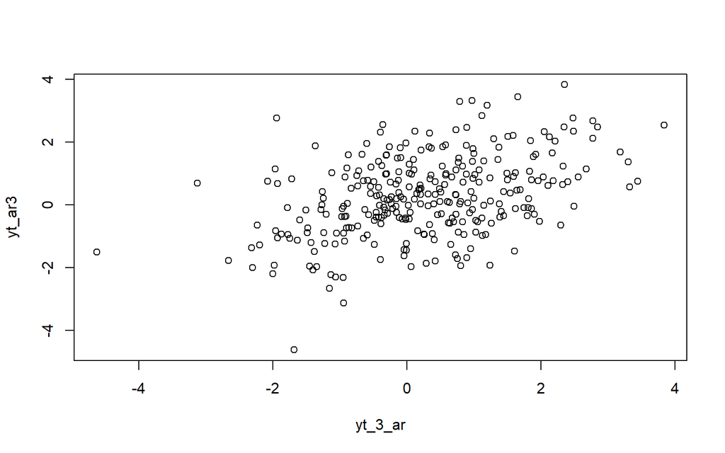

```r
plot(y=yt_ar3,x=yt_3_ar)
```

## Autokorelasi

### Antara $Y_t$ dengan $Y_{t-1}$

```r
cor(yt_ar,yt_1_ar)
```

```
## [1] 0.6078972
```

Korelasi berdasarkan pendekatan teoritis $\rho_1 = \frac {\phi_1} {1-\phi_2} = \frac{0.5}{1-0.2} = \frac{0.5} {0.8} = 0.625$

### Antara $Y_t$ dengan $Y_{t-2}$

```r
cor(yt_ar2,yt_2_ar)
```

```
## [1] 0.5366886
```

Korelasi berdasarkan pendekatan teoritis $\rho_2 = \phi_1\rho_1 + \phi_2 = 0.5\times0.625 + 0.2 = 0.5125$

### Antara $Y_t$ dengan $Y_{t-3}$

```r
cor(yt_ar3,yt_3_ar)
```

```
## [1] 0.4252969
```

Berdasarkan Scatter plot:

Hubungan $Y_t$ dan $Y_{t-1}$ bernilai positif, hal tersebut ditunjukkan juga dengan nilai korelasi data bangkitan = 0.608 dan berdekatan dengan korelasi secara teoritis = 0.625.

Hubungan $Y_t$ dan $Y_{t-2}$ bernilai positif, hal tersebut ditunjukkan juga dengan nilai korelasi data bangkitan = 0.537 dan berdekatan dengan korelasi secara teoritis = 0.513.

Hubungan $Y_t$ dan $Y_{t-3}$ bernilai positif, hal tersebut ditunjukkan juga dengan nilai korelasi data bangkitan = 0.425 dan berdekatan dengan nilai korelasi secara teoritis = 0.381.

# ARMA(2,2)

ARMA (2,2) dengan parameter $\theta_1 = 0.4$, $\theta_2 = 0.6$, $\phi_1 = 0.5$, dan $\phi_2 = 0.2$ sebanyak 300 observasi.

Model:
$$Y_t = 0.5Y_{t-1} + 0.2Y_{t-2} +
e_t + 0.4e_{t-1} + 0.6e_{t-2}$$

## Pembangkitan Data

### Manual

```r
set.seed(1080)
arma <- numeric(300)

arma[1] <- wn[1]
arma[2] <- 0.5 * arma[1] + wn[2] + 0.4 * wn[1]

for (i in 3:300) {
  arma[i] <- 0.5 * arma[i - 1] + 0.2 * arma[i - 2] +
                      wn[i] + 0.4 * wn[i - 1] + 0.6 * wn[i - 2]
}
arma
```

```
##   [1] -1.3476747527 -1.9203183315 -1.7078376066 -2.9486209556 -2.4855761595
##   [6] -1.8575105792 -2.8528651604 -1.7099970827 -1.9704393702 -0.0449381484
##  [11]  1.1697232416  1.1623919942  0.3956226382 -0.9439720503 -2.5056312122
##  [16] -1.7129609241 -1.3251764222 -1.1851472053 -2.1495315598 -2.8911247157
##  [21] -2.8569275042 -2.5066821207 -2.2511936990 -3.7571946757 -4.0529855424
##  [26] -4.7584869443 -4.0516769606 -4.0539882910 -2.5174625440 -2.4167480885
##  [31] -2.9713184592 -2.5208219327 -4.0656279687 -2.8493844727 -3.1543606935
##  [36] -2.6329215310 -1.4410687040 -0.6650395009  1.8821804176  2.3786099637
##  [41]  2.2614538479  2.6517855437  1.7370045796  3.1005273531  1.6040947940
##  [46]  1.3697838690  0.1524910919 -0.9071098570  0.6771414927 -0.5144707526
##  [51]  1.3921172940 -0.3121594404  0.3500754894  1.6398720345  1.3141141118
##  [56]  0.9011058531 -0.1545426296  0.2511687137 -0.3136680625  1.8358357280
##  [61] -0.8551100903 -0.1408309513 -2.4739751568 -0.5264158740  1.2412179671
##  [66]  0.2915718413  1.6098591546  0.6097804348  1.6799277001  0.5253079133
##  [71]  1.7948187047  0.0958441361  1.6967291791  1.6788473539  1.3294162278
```

[output cut: 45 more lines]

### Dengan arima.sim

```r
arma11 <- arima.sim(list(order=c(2,0,2), ar = c(0.5,0.2), ma = c(0.4,0.6)), n=300)
arma11
```

```
## Time Series:
## Start = 1
## End = 300
## Frequency = 1
##   [1] -4.0525284570 -2.5163496431 -2.4158996713 -2.9706716704 -2.5203288549
##   [6] -4.0652520720 -2.8490979088 -3.1541422322 -2.6327549876 -1.4409417400
##  [11] -0.6649427102  1.8822542058  2.3786662159  2.2614967316  2.6518182360
##  [16]  1.7370295025  3.1005463530  1.6041092785  1.3697949112  0.1524995100
##  [21] -0.9071034395  0.6771463851 -0.5144670229  1.3921201373 -0.3121572728
##  [26]  0.3500771419  1.6398732943  1.3141150722  0.9011065852 -0.1545420715
##  [31]  0.2511691392 -0.3136677382  1.8358359753 -0.8551099018 -0.1408308076
##  [36] -2.4739750473 -0.5264157905  1.2412180308  0.2915718898  1.6098591916
##  [41]  0.6097804630  1.6799277216  0.5253079297  1.7948187172  0.0958441456
##  [46]  1.6967291864  1.6788473595  1.3294162321  2.7244357077  0.4746053232
##  [51]  0.1144270184 -0.8789857506 -0.9616442835 -1.0711427200 -0.2915183241
```

[output cut: 49 more lines]

## Plot

### Plot Time Series

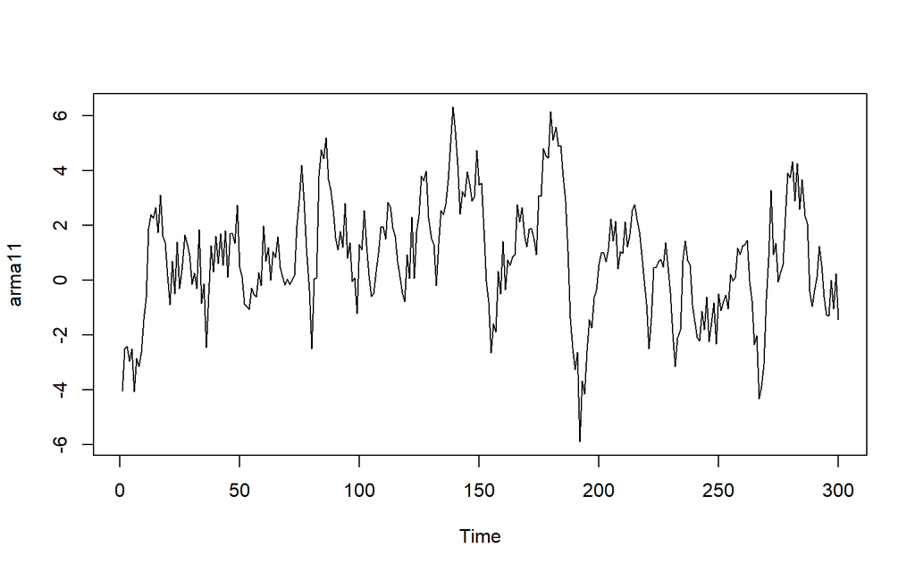

```r
ts.plot(arma11)
```

### Plot ACF dan PACF

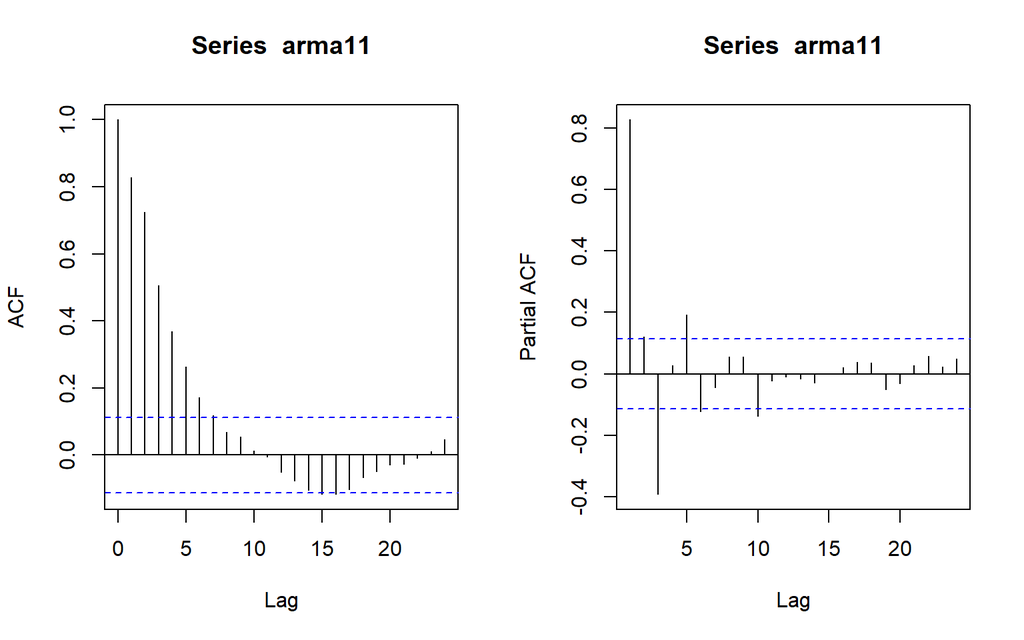

```r
par(mfrow = c(1, 2))
acf(arma11)
pacf(arma11)
```

### Plot EACF

```r
TSA::eacf(arma11)
```

```
## AR/MA
##   0 1 2 3 4 5 6 7 8 9 10 11 12 13
## 0 x x x x x x x o o o o  o  o  o
## 1 x x o o o o o o o o o  o  o  o
## 2 x x o o o o o o o o o  o  o  o
## 3 x x o o o o o o o o o  o  o  o
## 4 x x o x o o o o o o o  o  o  o
## 5 x x x o o o o o o o o  o  o  o
## 6 x x x o o o x o o o o  o  o  o
## 7 x x x o o o x x o o o  o  o  o
```

Berdasarkan plot time series, pergerakan data bangkitan berada di sekitar rataan konstan $E[Y_t] = 0$. Hal ini menunjukkan bahwa data ARMA(2,2) yang dibangkitkan stasioner dalam rataan.

Plot ACF dan PACF keduanya menunjukkan tail off yang menunjukkan bahwa data bangkitan merupakan proses ARMA(p,q) (sesuia dengan teori).

## Scatter Plot

### Antara $Y_t$ dengan $Y_{t-1}$

```r
#Yt
yt_arma <- arma11[-1]
yt_arma
```

```
##   [1] -2.5163496431 -2.4158996713 -2.9706716704 -2.5203288549 -4.0652520720
##   [6] -2.8490979088 -3.1541422322 -2.6327549876 -1.4409417400 -0.6649427102
##  [11]  1.8822542058  2.3786662159  2.2614967316  2.6518182360  1.7370295025
##  [16]  3.1005463530  1.6041092785  1.3697949112  0.1524995100 -0.9071034395
##  [21]  0.6771463851 -0.5144670229  1.3921201373 -0.3121572728  0.3500771419
##  [26]  1.6398732943  1.3141150722  0.9011065852 -0.1545420715  0.2511691392
##  [31] -0.3136677382  1.8358359753 -0.8551099018 -0.1408308076 -2.4739750473
##  [36] -0.5264157905  1.2412180308  0.2915718898  1.6098591916  0.6097804630
##  [41]  1.6799277216  0.5253079297  1.7948187172  0.0958441456  1.6967291864
##  [46]  1.6788473595  1.3294162321  2.7244357077  0.4746053232  0.1144270184
##  [51] -0.8789857506 -0.9616442835 -1.0711427200 -0.2915183241 -0.5214292779
##  [56] -0.6170883350  0.2688510998 -0.2012954342  1.9745608612  0.6832638347
##  [61]  1.1828711825 -0.0124188651  1.0402846856  0.8260033064  1.5778434345
##  [66]  0.4655960919  0.1160481769 -0.1880042851  0.0331438807 -0.1716487570
##  [71] -0.0009842747  0.1712741357  1.9822391848  2.9210014253  4.1969380438
```

[output cut: 45 more lines]

```r
#Yt-1
yt_1_arma <- arma11[-300]
yt_1_arma
```

```
##   [1] -4.0525284570 -2.5163496431 -2.4158996713 -2.9706716704 -2.5203288549
##   [6] -4.0652520720 -2.8490979088 -3.1541422322 -2.6327549876 -1.4409417400
##  [11] -0.6649427102  1.8822542058  2.3786662159  2.2614967316  2.6518182360
##  [16]  1.7370295025  3.1005463530  1.6041092785  1.3697949112  0.1524995100
##  [21] -0.9071034395  0.6771463851 -0.5144670229  1.3921201373 -0.3121572728
##  [26]  0.3500771419  1.6398732943  1.3141150722  0.9011065852 -0.1545420715
##  [31]  0.2511691392 -0.3136677382  1.8358359753 -0.8551099018 -0.1408308076
##  [36] -2.4739750473 -0.5264157905  1.2412180308  0.2915718898  1.6098591916
##  [41]  0.6097804630  1.6799277216  0.5253079297  1.7948187172  0.0958441456
##  [46]  1.6967291864  1.6788473595  1.3294162321  2.7244357077  0.4746053232
##  [51]  0.1144270184 -0.8789857506 -0.9616442835 -1.0711427200 -0.2915183241
##  [56] -0.5214292779 -0.6170883350  0.2688510998 -0.2012954342  1.9745608612
##  [61]  0.6832638347  1.1828711825 -0.0124188651  1.0402846856  0.8260033064
##  [66]  1.5778434345  0.4655960919  0.1160481769 -0.1880042851  0.0331438807
##  [71] -0.1716487570 -0.0009842747  0.1712741357  1.9822391848  2.9210014253
```

[output cut: 45 more lines]

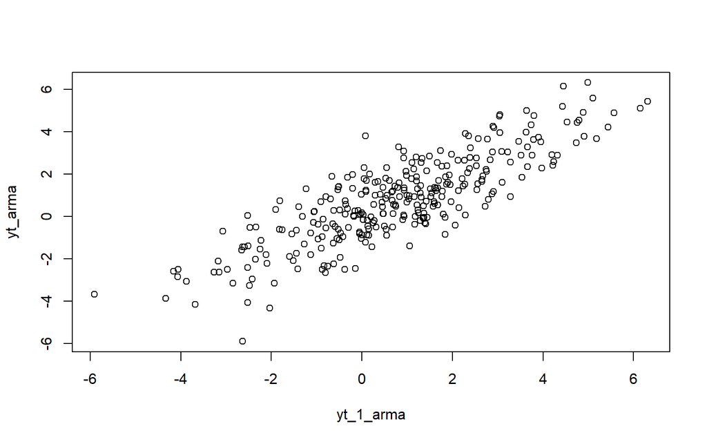

```r
plot(y=yt_arma,x=yt_1_arma)
```

### Antara $Y_t$ dengan $Y_{t-2}$

```r
#Yt
yt_arma2 <- arma11[-c(1,2)]
yt_arma2
```

```
##   [1] -2.4158996713 -2.9706716704 -2.5203288549 -4.0652520720 -2.8490979088
##   [6] -3.1541422322 -2.6327549876 -1.4409417400 -0.6649427102  1.8822542058
##  [11]  2.3786662159  2.2614967316  2.6518182360  1.7370295025  3.1005463530
##  [16]  1.6041092785  1.3697949112  0.1524995100 -0.9071034395  0.6771463851
##  [21] -0.5144670229  1.3921201373 -0.3121572728  0.3500771419  1.6398732943
##  [26]  1.3141150722  0.9011065852 -0.1545420715  0.2511691392 -0.3136677382
##  [31]  1.8358359753 -0.8551099018 -0.1408308076 -2.4739750473 -0.5264157905
##  [36]  1.2412180308  0.2915718898  1.6098591916  0.6097804630  1.6799277216
##  [41]  0.5253079297  1.7948187172  0.0958441456  1.6967291864  1.6788473595
##  [46]  1.3294162321  2.7244357077  0.4746053232  0.1144270184 -0.8789857506
##  [51] -0.9616442835 -1.0711427200 -0.2915183241 -0.5214292779 -0.6170883350
##  [56]  0.2688510998 -0.2012954342  1.9745608612  0.6832638347  1.1828711825
##  [61] -0.0124188651  1.0402846856  0.8260033064  1.5778434345  0.4655960919
##  [66]  0.1160481769 -0.1880042851  0.0331438807 -0.1716487570 -0.0009842747
##  [71]  0.1712741357  1.9822391848  2.9210014253  4.1969380438  2.9067521431
```

[output cut: 45 more lines]

```r
#Yt-1
yt_2_arma <- arma11[-c(299,300)]
yt_2_arma
```

```
##   [1] -4.0525284570 -2.5163496431 -2.4158996713 -2.9706716704 -2.5203288549
##   [6] -4.0652520720 -2.8490979088 -3.1541422322 -2.6327549876 -1.4409417400
##  [11] -0.6649427102  1.8822542058  2.3786662159  2.2614967316  2.6518182360
##  [16]  1.7370295025  3.1005463530  1.6041092785  1.3697949112  0.1524995100
##  [21] -0.9071034395  0.6771463851 -0.5144670229  1.3921201373 -0.3121572728
##  [26]  0.3500771419  1.6398732943  1.3141150722  0.9011065852 -0.1545420715
##  [31]  0.2511691392 -0.3136677382  1.8358359753 -0.8551099018 -0.1408308076
##  [36] -2.4739750473 -0.5264157905  1.2412180308  0.2915718898  1.6098591916
##  [41]  0.6097804630  1.6799277216  0.5253079297  1.7948187172  0.0958441456
##  [46]  1.6967291864  1.6788473595  1.3294162321  2.7244357077  0.4746053232
##  [51]  0.1144270184 -0.8789857506 -0.9616442835 -1.0711427200 -0.2915183241
##  [56] -0.5214292779 -0.6170883350  0.2688510998 -0.2012954342  1.9745608612
##  [61]  0.6832638347  1.1828711825 -0.0124188651  1.0402846856  0.8260033064
##  [66]  1.5778434345  0.4655960919  0.1160481769 -0.1880042851  0.0331438807
##  [71] -0.1716487570 -0.0009842747  0.1712741357  1.9822391848  2.9210014253
```

[output cut: 45 more lines]

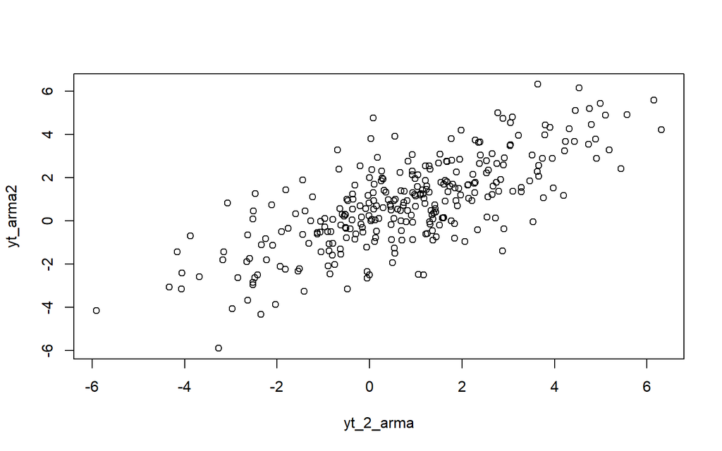

```r
plot(y=yt_arma2,x=yt_2_arma)
```

### Antara $Y_t$ dengan $Y_{t-3}$

```r
#Yt
yt_arma3 <- arma11[-c(1,2,3)]
yt_arma3
```

```
##   [1] -2.9706716704 -2.5203288549 -4.0652520720 -2.8490979088 -3.1541422322
##   [6] -2.6327549876 -1.4409417400 -0.6649427102  1.8822542058  2.3786662159
##  [11]  2.2614967316  2.6518182360  1.7370295025  3.1005463530  1.6041092785
##  [16]  1.3697949112  0.1524995100 -0.9071034395  0.6771463851 -0.5144670229
##  [21]  1.3921201373 -0.3121572728  0.3500771419  1.6398732943  1.3141150722
##  [26]  0.9011065852 -0.1545420715  0.2511691392 -0.3136677382  1.8358359753
##  [31] -0.8551099018 -0.1408308076 -2.4739750473 -0.5264157905  1.2412180308
##  [36]  0.2915718898  1.6098591916  0.6097804630  1.6799277216  0.5253079297
##  [41]  1.7948187172  0.0958441456  1.6967291864  1.6788473595  1.3294162321
##  [46]  2.7244357077  0.4746053232  0.1144270184 -0.8789857506 -0.9616442835
##  [51] -1.0711427200 -0.2915183241 -0.5214292779 -0.6170883350  0.2688510998
##  [56] -0.2012954342  1.9745608612  0.6832638347  1.1828711825 -0.0124188651
##  [61]  1.0402846856  0.8260033064  1.5778434345  0.4655960919  0.1160481769
##  [66] -0.1880042851  0.0331438807 -0.1716487570 -0.0009842747  0.1712741357
##  [71]  1.9822391848  2.9210014253  4.1969380438  2.9067521431  1.1637506816
```

[output cut: 45 more lines]

```r
#Yt-1
yt_3_arma <- arma11[-c(298,299,300)]
yt_3_arma
```

```
##   [1] -4.0525284570 -2.5163496431 -2.4158996713 -2.9706716704 -2.5203288549
##   [6] -4.0652520720 -2.8490979088 -3.1541422322 -2.6327549876 -1.4409417400
##  [11] -0.6649427102  1.8822542058  2.3786662159  2.2614967316  2.6518182360
##  [16]  1.7370295025  3.1005463530  1.6041092785  1.3697949112  0.1524995100
##  [21] -0.9071034395  0.6771463851 -0.5144670229  1.3921201373 -0.3121572728
##  [26]  0.3500771419  1.6398732943  1.3141150722  0.9011065852 -0.1545420715
##  [31]  0.2511691392 -0.3136677382  1.8358359753 -0.8551099018 -0.1408308076
##  [36] -2.4739750473 -0.5264157905  1.2412180308  0.2915718898  1.6098591916
##  [41]  0.6097804630  1.6799277216  0.5253079297  1.7948187172  0.0958441456
##  [46]  1.6967291864  1.6788473595  1.3294162321  2.7244357077  0.4746053232
##  [51]  0.1144270184 -0.8789857506 -0.9616442835 -1.0711427200 -0.2915183241
##  [56] -0.5214292779 -0.6170883350  0.2688510998 -0.2012954342  1.9745608612
##  [61]  0.6832638347  1.1828711825 -0.0124188651  1.0402846856  0.8260033064
##  [66]  1.5778434345  0.4655960919  0.1160481769 -0.1880042851  0.0331438807
##  [71] -0.1716487570 -0.0009842747  0.1712741357  1.9822391848  2.9210014253
```

[output cut: 45 more lines]

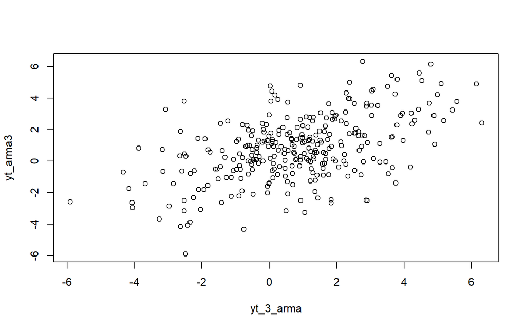

```r
plot(y=yt_arma3,x=yt_3_arma)
```

## Autokorelasi

### Antara $Y_t$ dengan $Y_{t-1}$

```r
cor(yt_arma,yt_1_arma)
```

```
## [1] 0.8371332
```

### Antara $Y_t$ dengan $Y_{t-2}$

```r
cor(yt_arma2,yt_2_arma)
```

```
## [1] 0.7349972
```

### Antara $Y_t$ dengan $Y_{t-3}$

```r
cor(yt_arma3,yt_3_arma)
```

```
## [1] 0.5160407
```

### Teoritis

$$\gamma_0 = \phi_1 \gamma_1 + \phi_2
\gamma_2 + \sigma^2 \left[ 1 + \theta_1(\phi_1 + \theta_1) +
\theta_2(\phi_1^2 + \phi_2 + \phi_1\theta_1 + \theta_2) \right]
\\$$

$$\gamma_1 = \phi_1 \gamma_0 + \phi_2
\gamma_1 + \sigma^2 \left[ \theta_1 + \theta_2(\phi_1 + \theta_1)
\right] \\$$

$$\gamma_2 = \phi_1 \gamma_1 + \phi_2
\gamma_0 + \sigma^2 \theta_2$$

Korelasi teoritis didapatkan dengan:

$\rho_k = \frac{\gamma_k}{\gamma_0}$ untuk $k < 3$ dan $\rho_k = \phi_1\rho_{k-1} + \phi_2\rho_{k-2}$ untuk $k\ge3$

Sehingga berdasarkan pendekatan teoritis nilai korelasi: $\rho_1 = 0.8592$, $\rho_2 = 0.7492$, dan $\rho_3 = 0.5464$

Berdasarkan Scatter plot:

Hubungan $Y_t$ dan $Y_{t-1}$ bernilai positif, hal tersebut ditunjukkan juga dengan nilai korelasi data bangkitan = 0.837 dan berdekatan dengan korelasi secara teoritis = 0.859.

Hubungan $Y_t$ dan $Y_{t-2}$ bernilai positif, hal tersebut ditunjukkan juga dengan nilai korelasi data bangkitan = 0.735 dan berdekatan dengan korelasi secara teoritis = 0.749.

Hubungan $Y_t$ dan $Y_{t-3}$ bernilai positif, hal tersebut ditunjukkan juga dengan nilai korelasi data bangkitan = 0.516 dan berdekatan dengan nilai korelasi secara teoritis = 0.546.